# Homework 6

Ismam Ferdous

2025-10-18

## Q1

Let’s use the Madison historical weather dataset for one more question.

```r
madison = read_csv("https://data.rcc-acis.org/StnData?sid=MSNthr&sdate=por&edate=por&elems=avgt,maxt,mint&output=csv",
                   skip=1, col_names=c("date","tavg","tmax","tmin"), show_col_types=F) %>% arrange(desc(date))
madison
```

```
## # A tibble: 57,268 × 4
##    date        tavg  tmax  tmin
##    <date>     <dbl> <dbl> <dbl>
##  1 2025-10-17  68      78    58
##  2 2025-10-16  59      66    52
##  3 2025-10-15  52      56    48
##  4 2025-10-14  54.5    66    43
##  5 2025-10-13  59      69    49
##  6 2025-10-12  56      67    45
##  7 2025-10-11  51.5    67    36
##  8 2025-10-10  59.5    73    46
##  9 2025-10-09  49.5    64    35
## 10 2025-10-08  50      62    38
## # ℹ 57,258 more rows
```

Get the last decade and a half of years (i.e. all data 2010-present) and find the mean tvg for each year AND month combination (you should end up with ~190 group averages).

Now, take this data and tabulate it with `pivot_wider()` so that each month is on its own column and each year on its own row. **Print this table out!**

Also show that with an appropriate `pivot_longer()` operation, you can pivot this table back into its longer form, cancelling out the `pivot_wider()` operation you just ran.

```r
# rearranging from 2010 to present :
madison_recent = madison %>%
  filter(lubridate::year(date) >= 2010)

# computing the mean average temp by year and month :
madison_summary = madison_recent %>%
  mutate(year = lubridate::year(date),
         month = lubridate::month(date)) %>%
  group_by(year, month) %>%
  summarise(mean_tavg = mean(tavg, na.rm = TRUE))
# pivoting the data wider : (months as columns)
madison_wide = madison_summary %>%
  pivot_wider(
    names_from = month,
    values_from = mean_tavg,
    names_prefix = "month_"
  )

madison_wide
```

```
## # A tibble: 16 × 13
## # Groups:   year [16]
##     year month_1 month_2 month_3 month_4 month_5 month_6 month_7 month_8 month_9
##    <dbl>   <dbl>   <dbl>   <dbl>   <dbl>   <dbl>   <dbl>   <dbl>   <dbl>   <dbl>
##  1  2010    16.9    23.1    38.9    52.2    59.9    68.5    74.7    73.7    61.0
##  2  2011    16.8    22.1    32.6    45.7    56.5    68.2    76.6    71.2    59.0
##  3  2012    25.5    29.6    50.1    47.9    63.4    71.6    79.4    70.7    60.6
##  4  2013    21.5    21.1    26.6    44.1    59.2    67.6    71.6    70.6    63.7
##  5  2014    11.4    12.2    27.7    45.4    59.7    70.4    68.9    71.0    60.6
##  6  2015    19.9    10.9    34.6    48.4    60.2    67.1    70.7    69.5    67.1
##  7  2016    19.9    26.9    39.9    45.8    58.5    69.2    72.9    72.4    65.9
##  8  2017    23.7    32.3    34.2    50.0    56.1    69.0    71.2    66.8    64.7
##  9  2018    20.1    21.5    32.7    37.6    64.5    69.2    72.3    71.5    63.7
## 10  2019    15.9    18.8    30.9    46.9    55.9    66.6    75.2    68.5    66.2
## 11  2020    26.1    23.1    38.4    44.9    56.3    69.8    75.0    70.4    59.8
## 12  2021    21.9    12.4    38.9    49.2    57.5    72.6    71.9    72.7    64.5
## 13  2022    14.4    21.4    34.4    43.4    62.1    69.0    72.7    70.3    63.1
## 14  2023    27.0    27.4    33.6    47.9    59.8    68.8    72.4    70.9    66.5
## 15  2024    22.9    33.8    39.5    49      61.9    70.4    72.2    70.9    65.9
## 16  2025    19.6    22.2    39.7    46.8    56.2    71      73.5    68.6    65.0
## # ℹ 3 more variables: month_10 <dbl>, month_11 <dbl>, month_12 <dbl>
```

```r
# pivoting back to long form
madison_long = madison_wide %>%
  pivot_longer(
    cols = starts_with("month_"),
    names_to = "month",
    values_to = "mean_tavg",
    names_prefix = "month_"
  )

madison_long
```

```
## # A tibble: 192 × 3
## # Groups:   year [16]
##     year month mean_tavg
##    <dbl> <chr>     <dbl>
##  1  2010 1          16.9
##  2  2010 2          23.1
##  3  2010 3          38.9
##  4  2010 4          52.2
##  5  2010 5          59.9
##  6  2010 6          68.5
##  7  2010 7          74.7
##  8  2010 8          73.7
##  9  2010 9          61.0
## 10  2010 10         52.2
## # ℹ 182 more rows
```

## Q2

For the next questions, let’s examine historic CO2 and ocean acidity data gathered from NOAA and the University of Hawaii.

As the amount of CO2 in the atmosphere rises, some CO2 can dissolve into the ocean, which lowers the pH of the water and increases acidity. This is a major environmental concern and can have significant impact on marine biodiversity.

The chunk below loads in the two datasets we will use (`co2_weekly_mlo.txt` and `HOT_surface_CO2.txt`) directly from the NOAA and U of Hawaii websites, and performs some basic data parsing like separating out comments, correcting NA values, and setting column names. From the `co2` dataset, we mainly care about the `ppm` column, which measure the amount of CO2 in the atmosphere in units of parts per million (i.e. number of CO2 particles in each million particles). From the `ph` dataset, we mainly care about the `ph` column, which contains estimated ocean pH at a reference temperature based on surface ocean pH measurements. These columns have been selected out for you.

```r
# use a slightly different function here due to unique table format
co2 = read_table("https://gml.noaa.gov/webdata/ccgg/trends/co2/co2_weekly_mlo.txt",
                 na="-999.99", comment="#", show_col_types=F,col_names=c(
                   "year","month","day","year.decimal","ppm","n.days","yr-1-ago","yr-10-ago","increase.1800")) %>%
  select(year, month, day, ppm)

ph = read_table("https://hahana.soest.hawaii.edu/hot/hotco2/HOT_surface_CO2.txt",skip=8,na="-999",show_col_types=F) %>%
  rename(ph=pHcalc_25C) %>% select(date, ph)
co2
```

```
## # A tibble: 2,683 × 4
##     year month   day   ppm
##    <dbl> <dbl> <dbl> <dbl>
##  1  1974     5    19  333.
##  2  1974     5    26  333.
##  3  1974     6     2  332.
##  4  1974     6     9  332.
##  5  1974     6    16  332.
##  6  1974     6    23  332.
##  7  1974     6    30  332.
##  8  1974     7     7  331.
##  9  1974     7    14  331.
## 10  1974     7    21  331.
## # ℹ 2,673 more rows
```

```r
ph
```

```
## # A tibble: 348 × 2
##    date         ph
##    <chr>     <dbl>
##  1 31-Oct-88  8.13
##  2 2-Dec-88   8.12
##  3 8-Jan-89   8.11
##  4 26-Feb-89  8.11
##  5 27-Mar-89  8.11
##  6 18-May-89  8.10
##  7 24-Jun-89  8.11
##  8 29-Jul-89  8.10
##  9 24-Aug-89  8.11
## 10 22-Sep-89  8.12
## # ℹ 338 more rows
```

For each dataset, ensure the following by either creating/editing appropriate columns:

- There should be a `date` column with a proper date-object giving the date of the observation,
- There should also be `year` and `month` columns giving the year/month of each observation,
  - `month` should be coded as “Jan”, “Feb”, …, “Dec” and these should have the natural ordering (if you use `month()` function with `label=TRUE` the ordering should be automatically done for you)
- Drop any rows with missing values anywhere

Start by making a line plot of each data set, showing the trend of each dataset over time. Also add a smoothed trend curve (and set `se=FALSE` to hide error bands). Describe the trends observed.

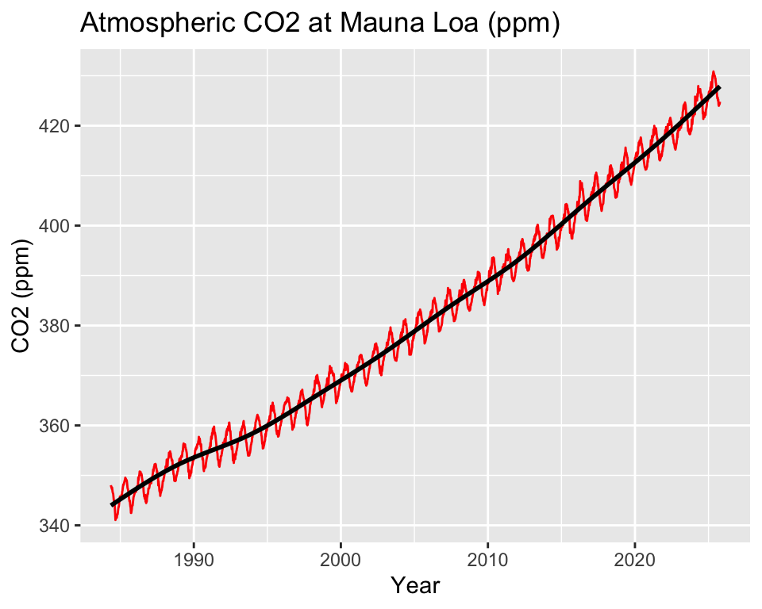

```r
library(lubridate)

# load and drop missing values :

# co2 :
co2 = read_table(
  "https://gml.noaa.gov/webdata/ccgg/trends/co2/co2_weekly_mlo.txt",
  na = "-999.99", comment = "#",
  col_names = c("year","month","day","year.decimal","ppm",
                "n.days","yr.1.ago","yr.10.ago","increase.1800"),
  show_col_types = FALSE
) %>%
  mutate(date = make_date(year, month, day),
         year = year(date),
         month = month(date, label = TRUE, abbr = TRUE)) %>%
  drop_na()

# pH:

ph = read_table(
  "https://hahana.soest.hawaii.edu/hot/hotco2/HOT_surface_CO2.txt",
  skip = 8, na = "-999", show_col_types = FALSE
) %>%
  rename(ph = pHcalc_25C) %>%
  mutate(date = as.Date(date, format = "%d-%b-%y"),
         year = year(date),
         month = month(date, label = TRUE, abbr = TRUE)) %>%
  drop_na()


# co2 graph :
ggplot(co2, aes(x=date, y=ppm)) +
  geom_line(color="red") +
  geom_smooth(se=FALSE, color="black") +
  labs(title="Atmospheric CO2 at Mauna Loa (ppm)",
       x="Year", y="CO2 (ppm)")
```

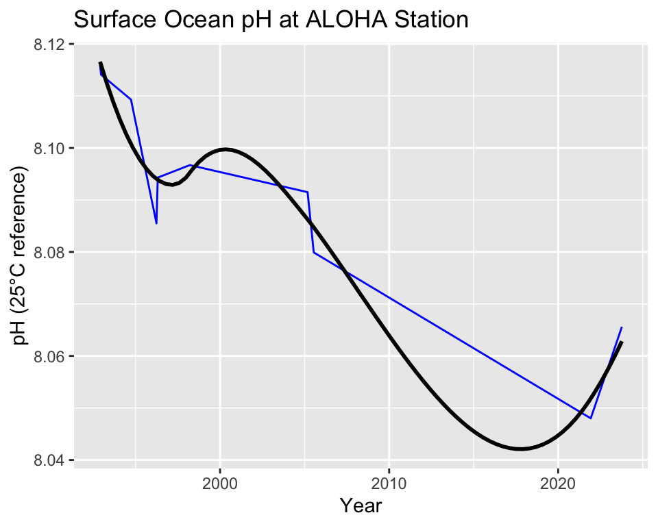

```r
# pH graph :

ggplot(ph, aes(x=date, y=ph)) +
  geom_line(color="blue") +
  geom_smooth(se=FALSE, color="black") +
  labs(title="Surface Ocean pH at ALOHA Station",
       x="Year", y="pH (25°C reference)")
```